# Building Features, Watching What Happens

MUSA 5080 · Integrates Weeks 1–5 · Due Friday, October 16

Author

Sophia Meyers

## Part 0: Setup

```r
library(tidyverse)
library(tidycensus)
library(sf)
library(caret)

Sys.getenv("CENSUS_API_KEY") != ""   # should print TRUE
```

```
[1] TRUE
```

### The cross-validation helper

```r
ctrl <- trainControl(method = "cv", number = 10)

cv_rmse <- function(formula, data) {
  df <- if (inherits(data, "sf")) st_drop_geometry(data) else data
  vars <- all.vars(formula)
  bad <- vars[sapply(vars, function(v) any(is.na(df[[v]])))]
  if (length(bad) > 0) {
    stop("These variables have NAs: ", paste(bad, collapse = ", "),
         ". Fill them or choose another variable (Rule 1: don't drop rows).")
  }
  set.seed(5080)
  fit <- train(formula, data = df, method = "lm", trControl = ctrl)
  fit$results$RMSE
}
```

### The model log

```r
model_log <- tibble(
  model   = character(),
  added   = character(),
  cv_rmse = numeric(),
  notes   = character()
)
```

## Part 1: Choose your outcome

### 1A: Pull your outcome and your baseline predictors

Choose **three to five ACS predictors** for your baseline model. They should be things that plausibly relate to your outcome, but **none of them may be built from your outcome** (Rule 3).

```r
load_variables(2023, "acs5")
```

```
# A tibble: 28,261 × 4
   name        label                                    concept        geography
   <chr>       <chr>                                    <chr>          <chr>
 1 B01001A_001 Estimate!!Total:                         Sex by Age (W… tract
 2 B01001A_002 Estimate!!Total:!!Male:                  Sex by Age (W… tract
 3 B01001A_003 Estimate!!Total:!!Male:!!Under 5 years   Sex by Age (W… tract
 4 B01001A_004 Estimate!!Total:!!Male:!!5 to 9 years    Sex by Age (W… tract
 5 B01001A_005 Estimate!!Total:!!Male:!!10 to 14 years  Sex by Age (W… tract
 6 B01001A_006 Estimate!!Total:!!Male:!!15 to 17 years  Sex by Age (W… tract
 7 B01001A_007 Estimate!!Total:!!Male:!!18 and 19 years Sex by Age (W… tract
 8 B01001A_008 Estimate!!Total:!!Male:!!20 to 24 years  Sex by Age (W… tract
 9 B01001A_009 Estimate!!Total:!!Male:!!25 to 29 years  Sex by Age (W… tract
10 B01001A_010 Estimate!!Total:!!Male:!!30 to 34 years  Sex by Age (W… tract
# ℹ 28,251 more rows
```

```r
philly_tracts <- get_acs(
  geography = "tract",
  state = "PA",
  county = "Philadelphia",
  variables = c(
    total_pop = "B01003_001",
    total_households = "B08201_001",
    no_vehicle = "B08201_002",
    median_income = "B19013_001",
    median_age = "B01002_001",
    total_occupied = "B25003_001",
    renter_occupied = "B25003_003"
  ),
  year = 2023,
  output = "wide",
  geometry = TRUE
) %>%
  st_transform(2272)
```

```r
philly_tracts <- philly_tracts %>%
  mutate(
    # build your outcome, e.g. a percentage:
    y = no_vehicleE / total_householdsE * 100,
    # and its reliability. For a percentage, use tidycensus::moe_prop();
    # for a median or count, use the E and M columns directly.
    y_moe = tidycensus::moe_prop(
      no_vehicleE,
      total_householdsE,
      no_vehicleM,
      total_householdsM
    ),
    y_cv  = (y_moe / 1.645) / y * 100,
    # your predictors:
    renter_pct = renter_occupiedE/total_occupiedE * 100
    )
```

### 1B: Is it reliable enough to model?

Before you commit, check three things.

```r
# How many tracts have no value for your outcome?
sum(is.na(philly_tracts$y))
```

```
[1] 20
```

```r
# How reliable is it?
summary(philly_tracts$y_cv)
```

```
   Min. 1st Qu.  Median    Mean 3rd Qu.    Max.     NAs
0.03572 0.17204 0.23410     Inf 0.31959     Inf      20
```

```r
philly_tracts %>%
  mutate(reliability = case_when(
    y_cv < 12  ~ "High",
    y_cv <= 40 ~ "Moderate",
    TRUE       ~ "Low"
  )) %>%
  st_drop_geometry() %>%
  count(reliability)
```

```
  reliability   n
1        High 387
2         Low  21
```

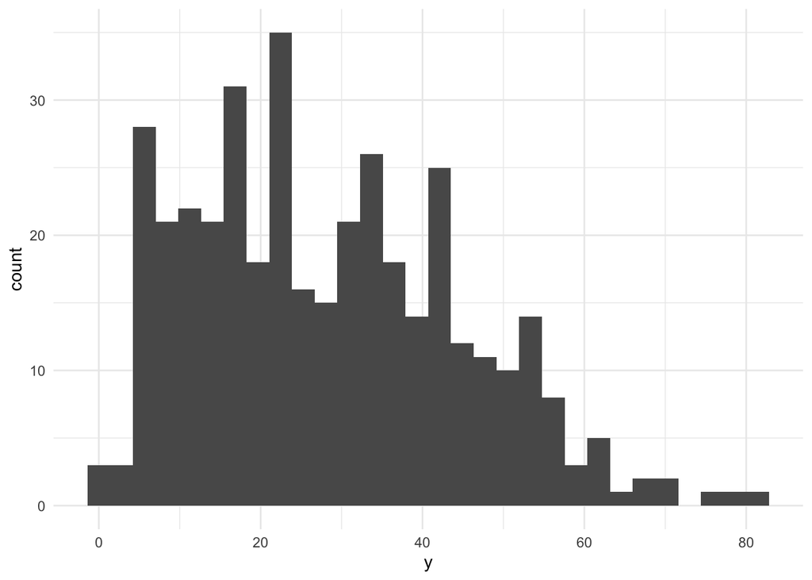

```r
# What does the distribution look like?
ggplot(philly_tracts, aes(x = y)) +
  geom_histogram(bins = 30) +
  theme_minimal()
```

```r
sum(is.na(philly_tracts$y))
```

```
[1] 20
```

```r
summary(philly_tracts$y_cv)
```

```
   Min. 1st Qu.  Median    Mean 3rd Qu.    Max.     NAs
0.03572 0.17204 0.23410     Inf 0.31959     Inf      20
```

If more than about a third of tracts have low reliability, consider a different outcome, or one built from larger counts. Write your reasoning either way.

**Answer:** What is your outcome, why would an agency want to predict it, and how reliable is it?

The outcome shows the percentage of households in each Philadelphia census tract that have no vehicle. An agency could use this measure to find areas where households may have greater transportation needs and may benefit from transportation services. The outcome is highly reliable because 387 of 388 tracts have high reliability, while only 1 tract has low reliability, which is far below one-third of the tracts.

### 1C: Decide which tracts to model

Filter once, here, and never again. Every later step uses `tracts`.

```r
tracts <- philly_tracts %>%
  filter(total_householdsE > 0,
         !is.na(y)
         # add !is.na() for each baseline predictor like in the in-class lab
         )

nrow(philly_tracts)
```

```
[1] 408
```

```r
nrow(tracts)
```

```
[1] 388
```

**Answer:** How many tracts did you lose, and what kinds of places are they?

## I lost 20 tracts. These are tracts with zero reported households, so the percentage of households without a vehicle cannot be calculated for them because there is no household denominator.

## Part 2: Baseline model

### 2A: Look first

Plot your outcome against each predictor before modeling (the Week 3 habit).

```r
income_median <- median(tracts$median_incomeE, na.rm = TRUE)

tracts <- tracts %>% # removing 7 empty variables
  mutate(
    median_incomeE = if_else(
      is.na(median_incomeE),
      income_median,
      median_incomeE
    )
  )
```

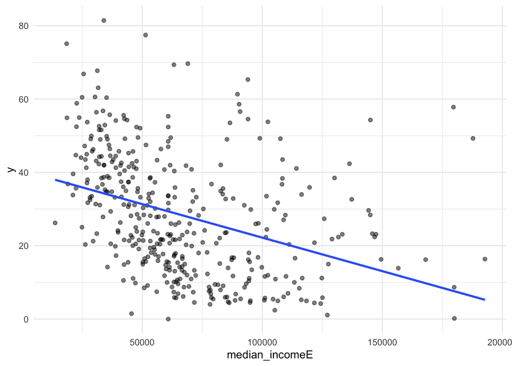

```r
# one scatterplot per predictor, e.g.:
 ggplot(tracts, aes(x = median_incomeE, y = y)) + geom_point(alpha = 0.5) +
   geom_smooth(method = "lm", se = FALSE) + theme_minimal()
```

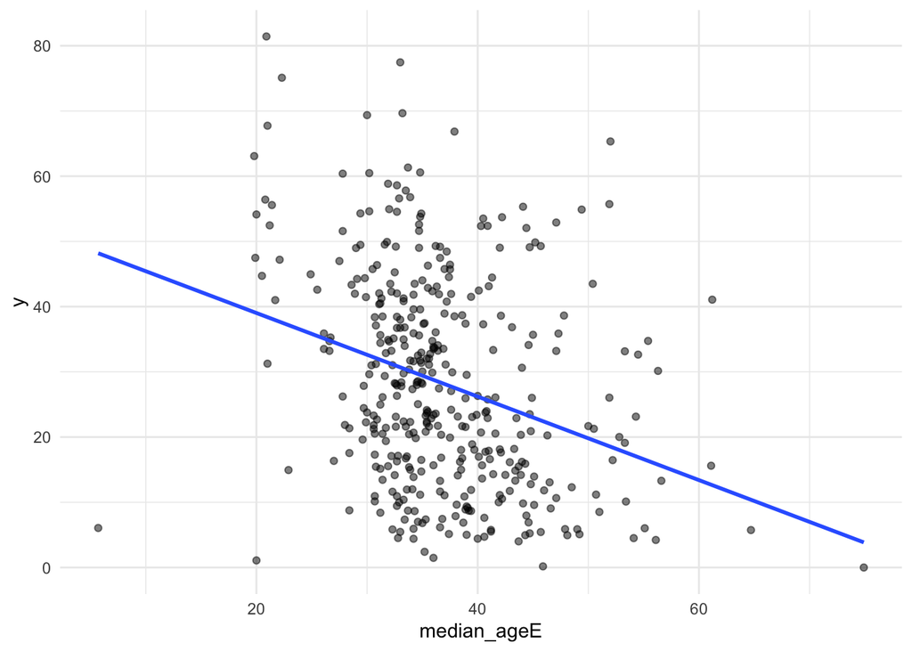

```r
# one scatterplot per predictor, e.g.:
 ggplot(tracts, aes(x = median_ageE, y = y)) + geom_point(alpha = 0.5) +
   geom_smooth(method = "lm", se = FALSE) + theme_minimal()
```

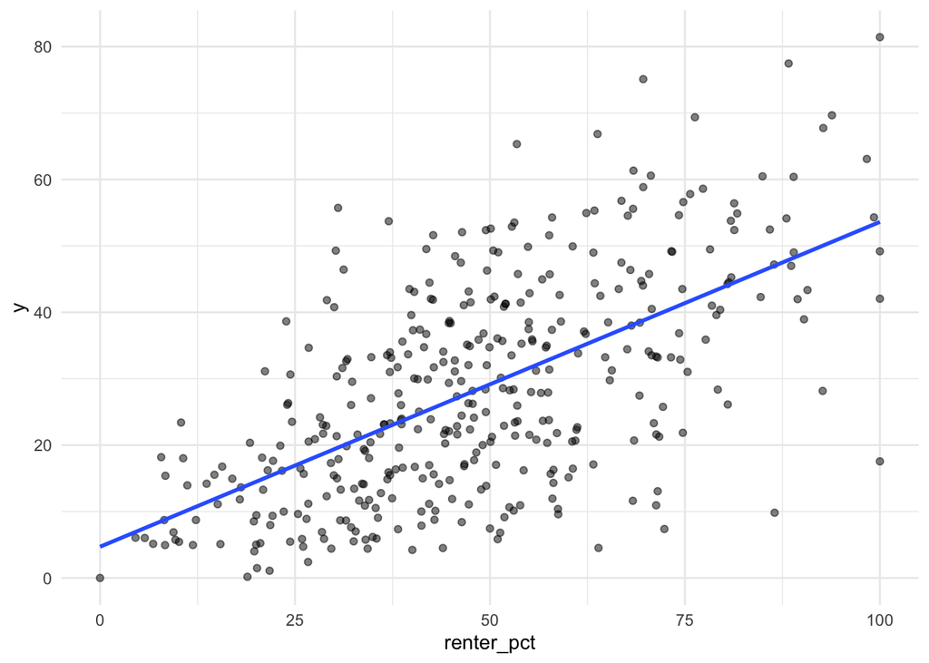

```r
# one scatterplot per predictor, e.g.:
 ggplot(tracts, aes(x = renter_pct, y = y)) + geom_point(alpha = 0.5) +
   geom_smooth(method = "lm", se = FALSE) + theme_minimal()
```

### 2B: Fit and log

```r
f1 <- y ~ median_incomeE + median_ageE + renter_pct

m1 <- lm(f1, data = tracts)
summary(m1)
```

```
Call:
lm(formula = f1, data = tracts)

Residuals:
    Min      1Q  Median      3Q     Max
-35.916  -7.747  -1.576   8.268  43.632

Coefficients:
                 Estimate Std. Error t value Pr(>|t|)
(Intercept)     2.051e+01  4.492e+00   4.567 6.69e-06 ***
median_incomeE -1.138e-04  1.985e-05  -5.732 2.01e-08 ***
median_ageE    -1.382e-01  8.878e-02  -1.557     0.12
renter_pct      4.241e-01  3.424e-02  12.386  < 2e-16 ***
---
Signif. codes:  0 '***' 0.001 '**' 0.01 '*' 0.05 '.' 0.1 ' ' 1

Residual standard error: 12.41 on 384 degrees of freedom
Multiple R-squared:  0.4289,    Adjusted R-squared:  0.4244
F-statistic: 96.11 on 3 and 384 DF,  p-value: < 2.2e-16
```

```r
model_log <- model_log %>%
  add_row(model = "m1", added = "ACS baseline",
          cv_rmse = cv_rmse(f1, tracts),
          notes = "Baseline model with income, age, and renter percentage")

model_log
```

```
# A tibble: 1 × 4
  model added        cv_rmse notes
  <chr> <chr>          <dbl> <chr>
1 m1    ACS baseline    12.4 Baseline model with income, age, and renter percen…
```

On tracts it hasn’t seen, the baseline model misses by about 12.44 percentage points, based on the cross-validation RMSE.

### 2C: Where is the baseline wrong?

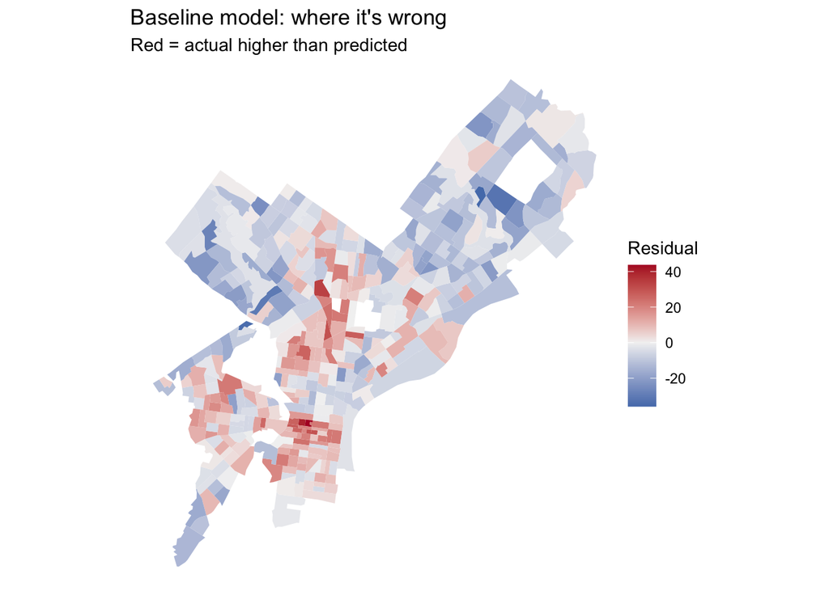

```r
tracts <- tracts %>% mutate(resid_m1 = residuals(m1))

ggplot(tracts) +
  geom_sf(aes(fill = resid_m1), color = NA) +
  scale_fill_gradient2(low = "#2166ac", mid = "grey95", high = "#b2182b", midpoint = 0) +
  theme_void() +
  labs(title = "Baseline model: where it's wrong",
       subtitle = "Red = actual higher than predicted",
       fill = "Residual")
```

**Answer:** Where do the residuals cluster? What might those places have in common that your model doesn’t know about?

The residual map shows spatial clustering, with positive residuals concentrated in parts of central and southern Philadelphia and negative residuals appearing in portions of northwestern and northeastern Philadelphia. Positive residuals indicate that the actual percentage of households without vehicles is higher than the model predicts, while negative residuals indicate that it is lower than predicted. Because the residuals are spatially patterned, median income, median age, and renter percentage do not fully explain geographic variation in vehicle ownership. The remaining patterns may reflect differences in public transportation access, neighborhood density, walk-ability, and proximity. These patterns suggest that adding transportation-accessibility or built-environment data could improve the model.

## Part 3: Getting data from Philadelphia’s open data portal

```r
carto_get <- function(sql) {
  url <- paste0("https://phl.carto.com/api/v2/sql?format=GeoJSON&q=", URLencode(sql))
  st_read(url, quiet = TRUE)
}
```

### Finding a table name

```r
# What kinds of crime are in the incidents table in 2023?
url <- paste0("https://phl.carto.com/api/v2/sql?format=csv&q=",
              URLencode("SELECT text_general_code, COUNT(*) AS n
                         FROM incidents_part1_part2
                         WHERE dispatch_date >= '2023-01-01' AND dispatch_date < '2024-01-01'
                         GROUP BY text_general_code ORDER BY n DESC"))
read_csv(url)
```

```
# A tibble: 32 × 2
   text_general_code                 n
   <chr>                         <dbl>
 1 Thefts                        37054
 2 Other Assaults                25986
 3 Motor Vehicle Theft           22478
 4 Vandalism/Criminal Mischief   17346
 5 All Other Offenses            13334
 6 Theft from Vehicle            13002
 7 Fraud                          7661
 8 Aggravated Assault No Firearm  5134
 9 Burglary Residential           3800
10 Aggravated Assault Firearm     3320
# ℹ 22 more rows
```

### Worked example: residential burglaries in 2023

```r
burglary <- carto_get(
  "SELECT the_geom, text_general_code, dispatch_date
   FROM incidents_part1_part2
   WHERE dispatch_date >= '2023-01-01' AND dispatch_date < '2024-01-01'
     AND text_general_code = 'Burglary Residential'"
) %>%
  st_transform(st_crs(tracts))    # Carto returns EPSG 4326; translate immediately

nrow(burglary)
```

```
[1] 3800
```